# Commute Mode, Household Income, and Travel Time Analysis

## New York City Census Tracts (ACS 2019-2023)

**IADS Presentation - Introduction to Applied Data Science**

This notebook analyzes the relationship between commute mode (driving alone vs. public transit), median household income, and average commute time using American Community Survey data from NHGIS.

**Geographic Focus**: NYC Boroughs (Manhattan, Brooklyn, Queens, Bronx, Staten Island)

## Step 1: Question/Hypothesis

### Research Questions

1. Is there a significant difference in median household income between census tracts dominated by solo-driving commuters versus tracts dominated by public transit commuters?
2. Is there a significant difference in average commute time between tracts with high public transit usage and tracts with high private vehicle usage?

### Hypotheses

**Hypothesis 1: Commute Mode and Income Level**

- H₀: There is no significant difference in median household income between car-dominated and transit-dominated census tracts
- H₁: Census tracts dominated by solo-driving commuters have significantly different median household incomes compared to tracts dominated by public transit commuters

**Hypothesis 2: Public Transit Use and Commute Time**

- H₀: There is no significant difference in average commute time between car-dominated and transit-dominated census tracts
- H₁: Census tracts with higher rates of public transit commuting have significantly longer average commute times than tracts dominated by private vehicle use

### Classification Approach

We use a **quartile-based classification** to compare extreme groups:

- **Car-dominated tracts**: Bottom 25% of public transit usage (highest car dependency)
- **Transit-dominated tracts**: Top 25% of public transit usage

This approach provides clearer separation between groups and is more robust than simple majority classification.

## Step 2: Data Acquisition and Assessment

```python
# Import libraries
import pandas as pd
import numpy as np
from scipy import stats
import matplotlib.pyplot as plt
import seaborn as sns

# Set display options
pd.set_option('display.max_columns', 50)
pd.set_option('display.float_format', '{:.2f}'.format)
sns.set_style('whitegrid')
plt.rcParams['figure.figsize'] = (10, 6)
```

```python
# Load the data
df = pd.read_csv('data/nhgis0009_csv/nhgis0009_ds267_20235_tract.csv', encoding='latin-1')

print(f"Dataset shape: {df.shape}")
print(f"Number of census tracts: {len(df)}")
print(f"\nColumns: {df.columns.tolist()[:20]}...")  # First 20 columns
```

```
Dataset shape: (5396, 314)
Number of census tracts: 5396

Columns: ['GISJOIN', 'YEAR', 'STUSAB', 'REGIONA', 'DIVISIONA', 'STATE', 'STATEA', 'COUNTY', 'COUNTYA', 'COUSUBA', 'PLACEA', 'TRACTA', 'BLKGRPA', 'CONCITA', 'AIANHHA', 'RES_ONLYA', 'TRUSTA', 'AIHHTLI', 'AITSA', 'ANRCA']...
```

```python
# Select relevant columns for analysis
# Key variable codes from codebook:
# - ASORE001: Total workers 16+
# - ASORE003: Drove alone
# - ASORE010: Public transportation (excl. taxicab)
# - ASOTE001-013: Travel time buckets
# - ASQPE001: Median household income

columns_to_keep = [
    # Geographic identifiers
    'GISJOIN', 'COUNTY', 'TRACTA', 'NAME_E',
    # Total population
    'ASN1E001',
    # Transportation mode
    'ASORE001',  # Total workers
    'ASORE003',  # Drove alone
    'ASORE010',  # Public transit
    'ASORE021',  # Worked from home
    # Travel time buckets
    'ASOTE001',  # Total (commuters, not WFH)
    'ASOTE002', 'ASOTE003', 'ASOTE004', 'ASOTE005', 'ASOTE006',
    'ASOTE007', 'ASOTE008', 'ASOTE009', 'ASOTE010', 'ASOTE011',
    'ASOTE012', 'ASOTE013',
    # Income
    'ASQPE001'  # Median household income
]

df_analysis = df[columns_to_keep].copy()
df_analysis.head()
```

|  | GISJOIN | COUNTY | TRACTA | NAME_E | ASN1E001 | ASORE001 | ASORE003 | ASORE010 | ASORE021 | ASOTE001 | ASOTE002 | ASOTE003 | ASOTE004 | ASOTE005 | ASOTE006 | ASOTE007 | ASOTE008 | ASOTE009 | ASOTE010 | ASOTE011 | ASOTE012 | ASOTE013 | ASQPE001 |
| --- | --- | --- | --- | --- | --- | --- | --- | --- | --- | --- | --- | --- | --- | --- | --- | --- | --- | --- | --- | --- | --- | --- | --- |
| 0 | G3600010000100 | Albany County | 100 | Census Tract 1, Albany County, New York | 2156 | 632 | 243 | 185 | 0 | 632 | 5 | 22 | 142 | 86 | 24 | 44 | 180 | 0 | 9 | 35 | 28 | 57 | 46797 |
| 1 | G3600010000201 | Albany County | 201 | Census Tract 2.01, Albany County, New York | 2519 | 1107 | 318 | 238 | 114 | 993 | 0 | 14 | 298 | 337 | 79 | 38 | 18 | 0 | 42 | 92 | 75 | 0 | 37218 |
| 2 | G3600010000202 | Albany County | 202 | Census Tract 2.02, Albany County, New York | 2436 | 1366 | 667 | 253 | 25 | 1341 | 0 | 227 | 272 | 229 | 38 | 33 | 235 | 28 | 40 | 222 | 0 | 17 | 34160 |
| 3 | G3600010000301 | Albany County | 301 | Census Tract 3.01, Albany County, New York | 2378 | 1053 | 433 | 387 | 0 | 1053 | 0 | 0 | 138 | 143 | 209 | 144 | 191 | 0 | 0 | 133 | 95 | 0 | 45547 |
| 4 | G3600010000302 | Albany County | 302 | Census Tract 3.02, Albany County, New York | 3273 | 1875 | 981 | 184 | 297 | 1578 | 18 | 282 | 592 | 161 | 217 | 137 | 47 | 0 | 0 | 57 | 36 | 31 | 54375 |

```python
# Rename columns for clarity
df_analysis = df_analysis.rename(columns={
    'ASN1E001': 'total_population',
    'ASORE001': 'total_workers',
    'ASORE003': 'drove_alone',
    'ASORE010': 'public_transit',
    'ASORE021': 'work_from_home',
    'ASOTE001': 'commuters_total',
    'ASQPE001': 'median_income'
})

df_analysis.info()
```

```
<class 'pandas.core.frame.DataFrame'>
RangeIndex: 5396 entries, 0 to 5395
Data columns (total 23 columns):
 #   Column            Non-Null Count  Dtype
---  ------            --------------  -----
 0   GISJOIN           5396 non-null   object
 1   COUNTY            5396 non-null   object
 2   TRACTA            5396 non-null   int64
 3   NAME_E            5396 non-null   object
 4   total_population  5396 non-null   int64
 5   total_workers     5396 non-null   int64
 6   drove_alone       5396 non-null   int64
 7   public_transit    5396 non-null   int64
 8   work_from_home    5396 non-null   int64
 9   commuters_total   5396 non-null   int64
 10  ASOTE002          5396 non-null   int64
 11  ASOTE003          5396 non-null   int64
 12  ASOTE004          5396 non-null   int64
 13  ASOTE005          5396 non-null   int64
 14  ASOTE006          5396 non-null   int64
 15  ASOTE007          5396 non-null   int64
 16  ASOTE008          5396 non-null   int64
 17  ASOTE009          5396 non-null   int64
 18  ASOTE010          5396 non-null   int64
 19  ASOTE011          5396 non-null   int64
 20  ASOTE012          5396 non-null   int64
 21  ASOTE013          5396 non-null   int64
 22  median_income     5396 non-null   int64
dtypes: int64(20), object(3)
memory usage: 969.7+ KB
```

```python
# Data quality checks
print("=== Data Quality Assessment ===")
print(f"\nTotal census tracts: {len(df_analysis)}")

# Check for missing/suppressed income values (-666666666)
missing_income = (df_analysis['median_income'] < 0).sum()
print(f"Tracts with missing/suppressed income: {missing_income} ({missing_income/len(df_analysis)*100:.1f}%)")

# Check for zero workers
zero_workers = (df_analysis['total_workers'] == 0).sum()
print(f"Tracts with zero workers: {zero_workers}")

# Check for null values
print(f"\nNull values per column:")
print(df_analysis.isnull().sum())
```

```
=== Data Quality Assessment ===

Total census tracts: 5396
Tracts with missing/suppressed income: 214 (4.0%)
Tracts with zero workers: 124

Null values per column:
GISJOIN             0
COUNTY              0
TRACTA              0
NAME_E              0
total_population    0
total_workers       0
drove_alone         0
public_transit      0
work_from_home      0
commuters_total     0
ASOTE002            0
ASOTE003            0
ASOTE004            0
ASOTE005            0
ASOTE006            0
ASOTE007            0
ASOTE008            0
ASOTE009            0
ASOTE010            0
ASOTE011            0
ASOTE012            0
ASOTE013            0
median_income       0
dtype: int64
```

```python
# Clean the data
# Remove tracts with missing income or zero workers
df_clean = df_analysis[
    (df_analysis['median_income'] > 0) &
    (df_analysis['total_workers'] > 0)
].copy()

print(f"NY State tracts after cleaning: {len(df_clean)}")

# Filter to NYC boroughs only
nyc_boroughs = ['New York County', 'Kings County', 'Queens County', 'Bronx County', 'Richmond County']
df_clean = df_clean[df_clean['COUNTY'].isin(nyc_boroughs)].copy()

print(f"NYC tracts: {len(df_clean)}")
print(f"\nBorough breakdown:")
borough_names = {
    'New York County': 'Manhattan',
    'Kings County': 'Brooklyn',
    'Queens County': 'Queens',
    'Bronx County': 'Bronx',
    'Richmond County': 'Staten Island'
}
for county, borough in borough_names.items():
    count = (df_clean['COUNTY'] == county).sum()
    print(f"  {borough}: {count} tracts")
```

```
NY State tracts after cleaning: 5182
NYC tracts: 2192

Borough breakdown:
  Manhattan: 297 tracts
  Brooklyn: 770 tracts
  Queens: 674 tracts
  Bronx: 334 tracts
  Staten Island: 117 tracts
```

## Step 3: Descriptive Analysis

```python
# Create derived variables

# Percentage of workers using each mode
df_clean['pct_drove_alone'] = df_clean['drove_alone'] / df_clean['total_workers'] * 100
df_clean['pct_public_transit'] = df_clean['public_transit'] / df_clean['total_workers'] * 100
df_clean['pct_work_from_home'] = df_clean['work_from_home'] / df_clean['total_workers'] * 100

# Calculate weighted average commute time using midpoints
# Time bucket midpoints (in minutes)
midpoints = {
    'ASOTE002': 2.5,   # <5 min
    'ASOTE003': 7,     # 5-9 min
    'ASOTE004': 12,    # 10-14 min
    'ASOTE005': 17,    # 15-19 min
    'ASOTE006': 22,    # 20-24 min
    'ASOTE007': 27,    # 25-29 min
    'ASOTE008': 32,    # 30-34 min
    'ASOTE009': 37,    # 35-39 min
    'ASOTE010': 42,    # 40-44 min
    'ASOTE011': 52,    # 45-59 min
    'ASOTE012': 75,    # 60-89 min
    'ASOTE013': 100    # 90+ min
}

# Calculate weighted sum of commute times
df_clean['weighted_time'] = sum(
    df_clean[col] * midpoint
    for col, midpoint in midpoints.items()
)

# Average commute time (weighted by number of commuters in each bucket)
df_clean['avg_commute_time'] = df_clean['weighted_time'] / df_clean['commuters_total']

# Handle division by zero (tracts with no commuters)
df_clean['avg_commute_time'] = df_clean['avg_commute_time'].replace([np.inf, -np.inf], np.nan)

print("Derived variables created successfully!")
```

```
Derived variables created successfully!
```

```python
# Summary statistics for key variables
summary_cols = ['median_income', 'pct_drove_alone', 'pct_public_transit', 'avg_commute_time', 'total_workers']

summary_stats = df_clean[summary_cols].describe()
print("=== Summary Statistics ===")
print(summary_stats.round(2))
```

```
=== Summary Statistics ===
       median_income  pct_drove_alone  pct_public_transit  avg_commute_time  \
count        2192.00          2192.00             2192.00           2192.00
mean        88549.24            24.89               44.63             45.28
std         42443.02            16.92               15.68              8.16
min         11612.00             0.00                0.00             14.29
25%         60240.75            10.78               33.76             40.77
50%         81981.50            21.92               45.12             46.25
75%        107326.75            36.30               56.40             50.63
max        250001.00            81.44              100.00             73.49

       total_workers
count        2192.00
mean         1789.41
std          1014.13
min             2.00
25%          1073.00
50%          1577.00
75%          2264.50
max          9553.00
```

```python
# Classify tracts using quartile-based approach
q25 = df_clean['pct_public_transit'].quantile(0.25)
q75 = df_clean['pct_public_transit'].quantile(0.75)

print(f"Public transit usage quartiles:")
print(f"  25th percentile: {q25:.1f}%")
print(f"  75th percentile: {q75:.1f}%")

# Create classification
def classify_tract(pct_transit, q25, q75):
    if pct_transit <= q25:
        return 'Car-dominated'
    elif pct_transit >= q75:
        return 'Transit-dominated'
    else:
        return 'Mixed'

df_clean['commute_type'] = df_clean['pct_public_transit'].apply(
    lambda x: classify_tract(x, q25, q75)
)

print(f"\nTract classification:")
print(df_clean['commute_type'].value_counts())
```

```
Public transit usage quartiles:
  25th percentile: 33.8%
  75th percentile: 56.4%

Tract classification:
commute_type
Mixed                1096
Car-dominated         548
Transit-dominated     548
Name: count, dtype: int64
```

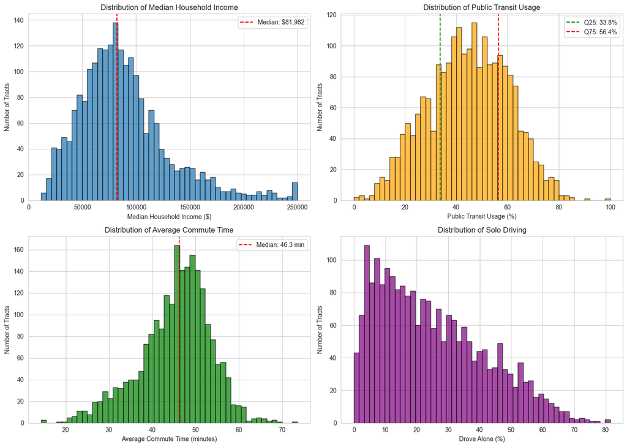

```python
# Visualizations - Distributions
fig, axes = plt.subplots(2, 2, figsize=(14, 10))

# 1. Median Income Distribution
ax1 = axes[0, 0]
ax1.hist(df_clean['median_income'], bins=50, edgecolor='black', alpha=0.7)
ax1.axvline(df_clean['median_income'].median(), color='red', linestyle='--', label=f"Median: ${df_clean['median_income'].median():,.0f}")
ax1.set_xlabel('Median Household Income ($)')
ax1.set_ylabel('Number of Tracts')
ax1.set_title('Distribution of Median Household Income')
ax1.legend()

# 2. Public Transit Usage Distribution
ax2 = axes[0, 1]
ax2.hist(df_clean['pct_public_transit'], bins=50, edgecolor='black', alpha=0.7, color='orange')
ax2.axvline(q25, color='green', linestyle='--', label=f'Q25: {q25:.1f}%')
ax2.axvline(q75, color='red', linestyle='--', label=f'Q75: {q75:.1f}%')
ax2.set_xlabel('Public Transit Usage (%)')
ax2.set_ylabel('Number of Tracts')
ax2.set_title('Distribution of Public Transit Usage')
ax2.legend()

# 3. Average Commute Time Distribution
ax3 = axes[1, 0]
ax3.hist(df_clean['avg_commute_time'].dropna(), bins=50, edgecolor='black', alpha=0.7, color='green')
ax3.axvline(df_clean['avg_commute_time'].median(), color='red', linestyle='--', label=f"Median: {df_clean['avg_commute_time'].median():.1f} min")
ax3.set_xlabel('Average Commute Time (minutes)')
ax3.set_ylabel('Number of Tracts')
ax3.set_title('Distribution of Average Commute Time')
ax3.legend()

# 4. Drove Alone Distribution
ax4 = axes[1, 1]
ax4.hist(df_clean['pct_drove_alone'], bins=50, edgecolor='black', alpha=0.7, color='purple')
ax4.set_xlabel('Drove Alone (%)')
ax4.set_ylabel('Number of Tracts')
ax4.set_title('Distribution of Solo Driving')

plt.tight_layout()
plt.show()
```

```
Downloading NY census tract geometries (first run may take a minute)...
Successfully merged 2192 tracts with geometries
NYC tracts: 2192
```

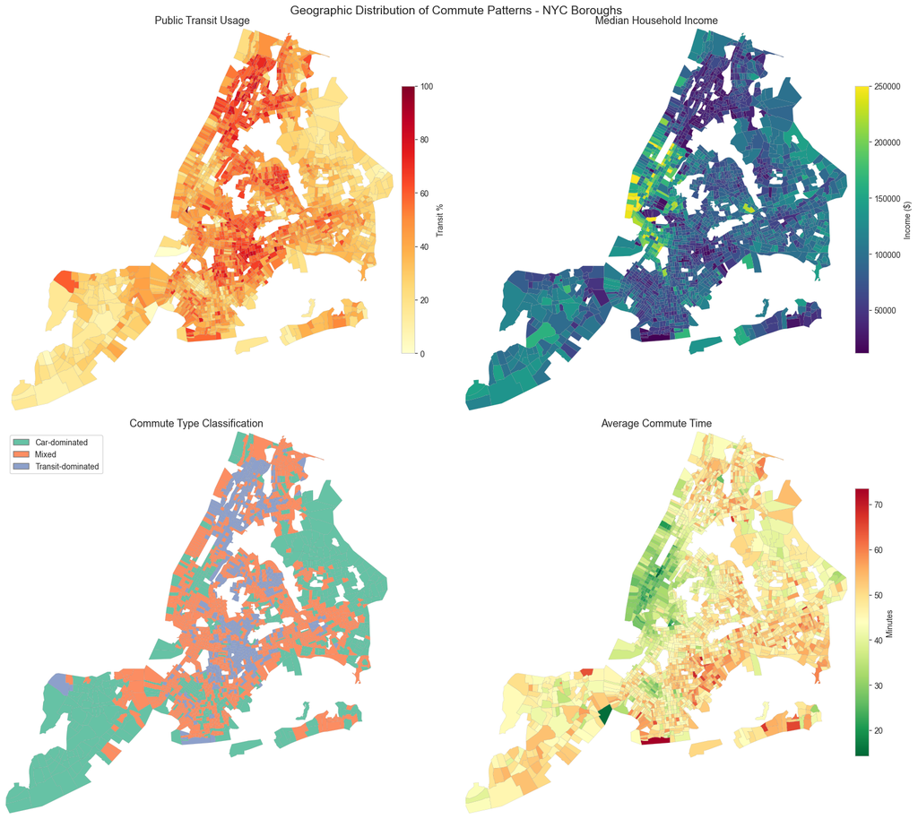

```
=== NYC Borough Summary ===
Manhattan       - Transit: 44.8%, Income: $121,528, Commute: 33.5 min
Brooklyn        - Transit: 47.1%, Income: $86,579, Commute: 46.4 min
Queens          - Transit: 41.2%, Income: $90,421, Commute: 47.6 min
Bronx           - Transit: 52.6%, Income: $56,330, Commute: 48.0 min
Staten Island   - Transit: 25.0%, Income: $98,996, Commute: 46.5 min
```

```python
# Geographic Visualization - Choropleth Maps (NYC Boroughs Only)
import geopandas as gpd
import pygris
from matplotlib.patches import Patch

print("Downloading NY census tract geometries (first run may take a minute)...")
ny_tracts = pygris.tracts(state="NY", year=2023)

# Create GEOID to match pygris/TIGER format
df_clean['GEOID'] = df_clean['GISJOIN'].str[1:3] + df_clean['GISJOIN'].str[4:7] + df_clean['GISJOIN'].str[8:]

# Merge geometries with analysis data
gdf = ny_tracts.merge(df_clean, on='GEOID', how='inner')
print(f"Successfully merged {len(gdf)} tracts with geometries")

# Filter to NYC boroughs only
nyc_boroughs = ['New York County', 'Kings County', 'Queens County', 'Bronx County', 'Richmond County']
gdf_nyc = gdf[gdf['COUNTY'].isin(nyc_boroughs)].copy()
print(f"NYC tracts: {len(gdf_nyc)}")

# Create 2x2 choropleth maps for NYC
fig, axes = plt.subplots(2, 2, figsize=(16, 14), constrained_layout=True)

# Get bounds for consistent axis limits
bounds = gdf_nyc.total_bounds  # [minx, miny, maxx, maxy]

# Map 1: Public Transit Usage
gdf_nyc.plot(column='pct_public_transit', cmap='YlOrRd', legend=True,
             legend_kwds={'label': 'Transit %', 'shrink': 0.7, 'pad': 0.02},
             ax=axes[0,0], edgecolor='gray', linewidth=0.1,
             missing_kwds={'color': 'lightgrey'})
axes[0,0].set_title('Public Transit Usage', fontsize=13)
axes[0,0].axis('off')
axes[0,0].set_xlim(bounds[0], bounds[2])
axes[0,0].set_ylim(bounds[1], bounds[3])

# Map 2: Median Household Income
gdf_nyc.plot(column='median_income', cmap='viridis', legend=True,
             legend_kwds={'label': 'Income ($)', 'shrink': 0.7, 'pad': 0.02},
             ax=axes[0,1], edgecolor='gray', linewidth=0.1,
             missing_kwds={'color': 'lightgrey'})
axes[0,1].set_title('Median Household Income', fontsize=13)
axes[0,1].axis('off')
axes[0,1].set_xlim(bounds[0], bounds[2])
axes[0,1].set_ylim(bounds[1], bounds[3])

# Map 3: Commute Type Classification
color_map = {'Car-dominated': '#66c2a5', 'Mixed': '#fc8d62', 'Transit-dominated': '#8da0cb'}
gdf_nyc['color'] = gdf_nyc['commute_type'].map(color_map)
gdf_nyc.plot(color=gdf_nyc['color'], ax=axes[1,0], edgecolor='gray', linewidth=0.1)
axes[1,0].set_title('Commute Type Classification', fontsize=13)
axes[1,0].axis('off')
axes[1,0].set_xlim(bounds[0], bounds[2])
axes[1,0].set_ylim(bounds[1], bounds[3])
legend_elements = [
    Patch(facecolor='#66c2a5', edgecolor='gray', label='Car-dominated'),
    Patch(facecolor='#fc8d62', edgecolor='gray', label='Mixed'),
    Patch(facecolor='#8da0cb', edgecolor='gray', label='Transit-dominated')
]
axes[1,0].legend(handles=legend_elements, loc='upper left', fontsize=10)

# Map 4: Average Commute Time
gdf_nyc.plot(column='avg_commute_time', cmap='RdYlGn_r', legend=True,
             legend_kwds={'label': 'Minutes', 'shrink': 0.7, 'pad': 0.02},
             ax=axes[1,1], edgecolor='gray', linewidth=0.1,
             missing_kwds={'color': 'lightgrey'})
axes[1,1].set_title('Average Commute Time', fontsize=13)
axes[1,1].axis('off')
axes[1,1].set_xlim(bounds[0], bounds[2])
axes[1,1].set_ylim(bounds[1], bounds[3])

fig.suptitle('Geographic Distribution of Commute Patterns - NYC Boroughs', fontsize=15, y=1.01)
plt.show()

# Print borough breakdown
print("\n=== NYC Borough Summary ===")
borough_names = {
    'New York County': 'Manhattan',
    'Kings County': 'Brooklyn',
    'Queens County': 'Queens',
    'Bronx County': 'Bronx',
    'Richmond County': 'Staten Island'
}
for county, borough in borough_names.items():
    subset = gdf_nyc[gdf_nyc['COUNTY'] == county]
    print(f"{borough:15} - Transit: {subset['pct_public_transit'].mean():.1f}%, "
          f"Income: ${subset['median_income'].mean():,.0f}, "
          f"Commute: {subset['avg_commute_time'].mean():.1f} min")
```

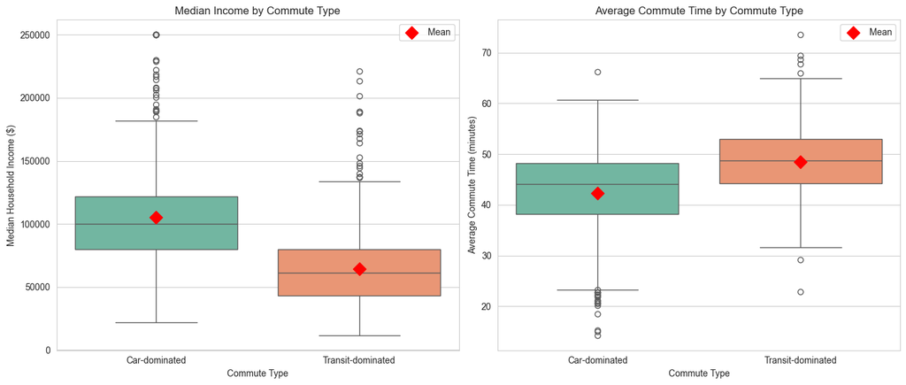

```python
# Box plots comparing groups
fig, axes = plt.subplots(1, 2, figsize=(14, 6))

# Filter to just car-dominated and transit-dominated (exclude mixed)
df_extreme = df_clean[df_clean['commute_type'] != 'Mixed'].copy()

# 1. Income by Commute Type
ax1 = axes[0]
order = ['Car-dominated', 'Transit-dominated']
sns.boxplot(data=df_extreme, x='commute_type', y='median_income', order=order, ax=ax1, palette='Set2')
ax1.set_xlabel('Commute Type')
ax1.set_ylabel('Median Household Income ($)')
ax1.set_title('Median Income by Commute Type')

# Add mean markers
means = df_extreme.groupby('commute_type')['median_income'].mean()
for i, ct in enumerate(order):
    ax1.scatter(i, means[ct], color='red', s=100, zorder=5, marker='D', label='Mean' if i==0 else '')
ax1.legend()

# 2. Commute Time by Commute Type
ax2 = axes[1]
sns.boxplot(data=df_extreme, x='commute_type', y='avg_commute_time', order=order, ax=ax2, palette='Set2')
ax2.set_xlabel('Commute Type')
ax2.set_ylabel('Average Commute Time (minutes)')
ax2.set_title('Average Commute Time by Commute Type')

# Add mean markers
means = df_extreme.groupby('commute_type')['avg_commute_time'].mean()
for i, ct in enumerate(order):
    ax2.scatter(i, means[ct], color='red', s=100, zorder=5, marker='D', label='Mean' if i==0 else '')
ax2.legend()

plt.tight_layout()
plt.show()
```

## Step 4: Exploratory Analysis

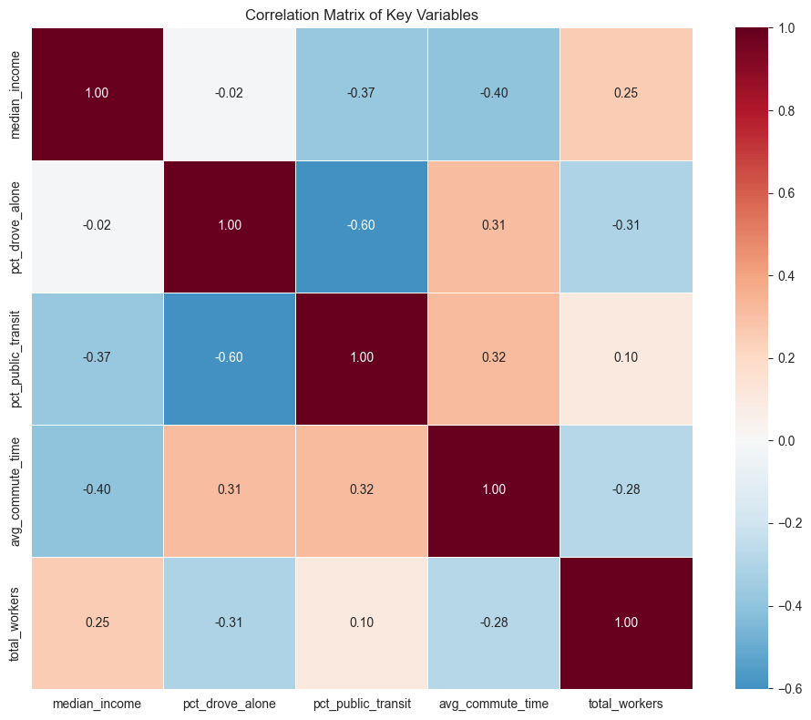

```python
# Correlation matrix
corr_cols = ['median_income', 'pct_drove_alone', 'pct_public_transit', 'avg_commute_time', 'total_workers']
corr_matrix = df_clean[corr_cols].corr()

plt.figure(figsize=(10, 8))
sns.heatmap(corr_matrix, annot=True, cmap='RdBu_r', center=0,
            fmt='.2f', square=True, linewidths=0.5)
plt.title('Correlation Matrix of Key Variables')
plt.tight_layout()
plt.show()
```

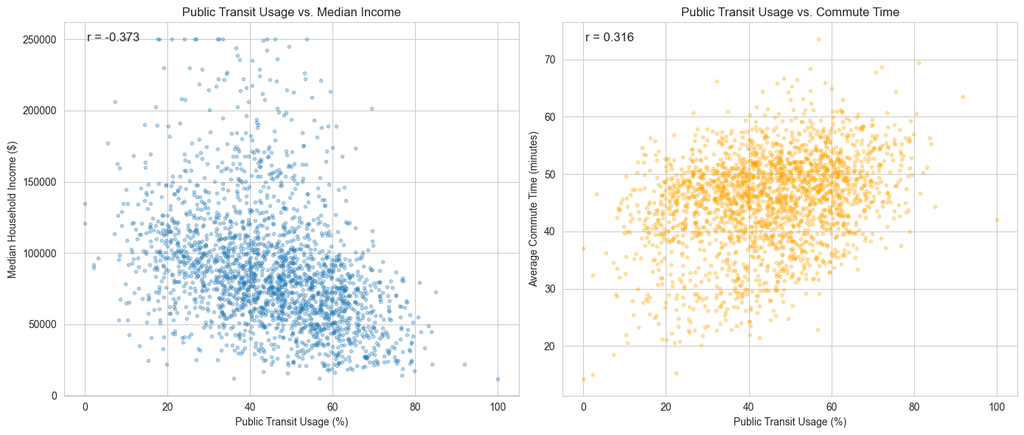

```python
# Scatter plot: Transit Usage vs Income
fig, axes = plt.subplots(1, 2, figsize=(14, 6))

# 1. Transit % vs Income
ax1 = axes[0]
ax1.scatter(df_clean['pct_public_transit'], df_clean['median_income'], alpha=0.3, s=10)
ax1.set_xlabel('Public Transit Usage (%)')
ax1.set_ylabel('Median Household Income ($)')
ax1.set_title('Public Transit Usage vs. Median Income')

# Add correlation annotation
corr = df_clean['pct_public_transit'].corr(df_clean['median_income'])
ax1.annotate(f'r = {corr:.3f}', xy=(0.05, 0.95), xycoords='axes fraction', fontsize=12)

# 2. Transit % vs Commute Time
ax2 = axes[1]
ax2.scatter(df_clean['pct_public_transit'], df_clean['avg_commute_time'], alpha=0.3, s=10, color='orange')
ax2.set_xlabel('Public Transit Usage (%)')
ax2.set_ylabel('Average Commute Time (minutes)')
ax2.set_title('Public Transit Usage vs. Commute Time')

# Add correlation annotation
corr = df_clean['pct_public_transit'].corr(df_clean['avg_commute_time'])
ax2.annotate(f'r = {corr:.3f}', xy=(0.05, 0.95), xycoords='axes fraction', fontsize=12)

plt.tight_layout()
plt.show()
```

```python
# Summary by group
print("=== Summary Statistics by Commute Type ===")
group_summary = df_extreme.groupby('commute_type')[['median_income', 'avg_commute_time', 'pct_public_transit', 'pct_drove_alone']].agg(['mean', 'median', 'std', 'count'])
print(group_summary.round(2))
```

```
=== Summary Statistics by Commute Type ===
                  median_income                         avg_commute_time  \
                           mean   median      std count             mean
commute_type
Car-dominated         105285.05 99818.00 41047.47   548            42.28
Transit-dominated      64479.20 61313.50 31806.01   548            48.50

                                    pct_public_transit                    \
                  median  std count               mean median  std count
commute_type
Car-dominated      44.11 8.63   548              24.10  25.18 6.92   548
Transit-dominated  48.78 6.76   548              64.41  62.67 6.48   548

                  pct_drove_alone
                             mean median   std count
commute_type
Car-dominated               40.11  44.64 18.90   548
Transit-dominated           13.78  12.72  7.44   548
```

## Step 5: Statistical Testing

```python
# Prepare data for hypothesis testing
car_dominated = df_extreme[df_extreme['commute_type'] == 'Car-dominated']
transit_dominated = df_extreme[df_extreme['commute_type'] == 'Transit-dominated']

print(f"Car-dominated tracts: n = {len(car_dominated)}")
print(f"Transit-dominated tracts: n = {len(transit_dominated)}")

# Check normality assumption for t-test
print("\n" + "=" * 60)
print("ASSUMPTION CHECK: Normality (Shapiro-Wilk Test)")
print("=" * 60)
print("Note: For large samples, Shapiro-Wilk is very sensitive.")
print("      We'll also examine skewness and visual inspection.\n")

from scipy.stats import shapiro, skew, kurtosis

# Sample for Shapiro-Wilk (max 5000)
for var_name, var_car, var_transit in [
    ('Median Income', car_dominated['median_income'], transit_dominated['median_income']),
    ('Avg Commute Time', car_dominated['avg_commute_time'].dropna(), transit_dominated['avg_commute_time'].dropna())
]:
    print(f"\n{var_name}:")

    # Skewness and Kurtosis
    skew_car, skew_transit = skew(var_car), skew(var_transit)
    kurt_car, kurt_transit = kurtosis(var_car), kurtosis(var_transit)

    print(f"  Car-dominated:     Skewness = {skew_car:.2f}, Kurtosis = {kurt_car:.2f}")
    print(f"  Transit-dominated: Skewness = {skew_transit:.2f}, Kurtosis = {kurt_transit:.2f}")

    # Shapiro-Wilk (on sample if n > 5000)
    sample_car = var_car.sample(min(len(var_car), 5000), random_state=42)
    sample_transit = var_transit.sample(min(len(var_transit), 5000), random_state=42)

    stat_car, p_car = shapiro(sample_car)
    stat_transit, p_transit = shapiro(sample_transit)

    print(f"  Shapiro-Wilk Car:     W = {stat_car:.4f}, p = {p_car:.4e}")
    print(f"  Shapiro-Wilk Transit: W = {stat_transit:.4f}, p = {p_transit:.4e}")
```

```
Car-dominated tracts: n = 548
Transit-dominated tracts: n = 548

============================================================
ASSUMPTION CHECK: Normality (Shapiro-Wilk Test)
============================================================
Note: For large samples, Shapiro-Wilk is very sensitive.
      We'll also examine skewness and visual inspection.


Median Income:
  Car-dominated:     Skewness = 1.15, Kurtosis = 2.16
  Transit-dominated: Skewness = 1.38, Kurtosis = 3.51
  Shapiro-Wilk Car:     W = 0.9279, p = 1.4598e-15
  Shapiro-Wilk Transit: W = 0.9132, p = 3.5869e-17

Avg Commute Time:
  Car-dominated:     Skewness = -0.74, Kurtosis = 0.21
  Transit-dominated: Skewness = -0.07, Kurtosis = 0.43
  Shapiro-Wilk Car:     W = 0.9530, p = 3.3547e-12
  Shapiro-Wilk Transit: W = 0.9955, p = 1.1558e-01
```

```python
# Test Selection Decision Based on Normality Check
print("=" * 70)
print("TEST SELECTION DECISION")
print("=" * 70)

from scipy.stats import skew

# Get skewness values
income_car = car_dominated['median_income']
income_transit = transit_dominated['median_income']
time_car = car_dominated['avg_commute_time'].dropna()
time_transit = transit_dominated['avg_commute_time'].dropna()

skew_income_car = skew(income_car)
skew_income_transit = skew(income_transit)
skew_time_car = skew(time_car)
skew_time_transit = skew(time_transit)

print("""
┌─────────────────┬────────────────────┬─────────────────────────┬─────────────────────┐
│ Variable        │ Skewness           │ Distribution            │ Test Selected       │
├─────────────────┼────────────────────┼─────────────────────────┼─────────────────────┤""")
print(f"│ Median Income   │ {skew_income_car:.2f} / {skew_income_transit:.2f}        │ Highly right-skewed     │ Mann-Whitney U      │")
print(f"│ Commute Time    │ {skew_time_car:.2f} / {skew_time_transit:.2f}      │ Approximately symmetric │ Welch's t-test      │")
print("""└─────────────────┴────────────────────┴─────────────────────────┴─────────────────────┘

Decision Rules:
  • |Skewness| > 1.0  → Highly skewed    → Use non-parametric test (Mann-Whitney U)
  • |Skewness| < 0.5  → Approx. symmetric → Use parametric test (t-test)
  • Levene's test p < 0.05 → Unequal variances → Use Welch's t-test (not standard t-test)
""")

# Helper function for Cohen's d effect size
def cohens_d(group1, group2):
    n1, n2 = len(group1), len(group2)
    var1, var2 = group1.var(), group2.var()
    pooled_std = np.sqrt(((n1-1)*var1 + (n2-1)*var2) / (n1+n2-2))
    return (group1.mean() - group2.mean()) / pooled_std

def interpret_cohens_d(d):
    d_abs = abs(d)
    if d_abs < 0.2:
        return "negligible"
    elif d_abs < 0.5:
        return "small"
    elif d_abs < 0.8:
        return "medium"
    else:
        return "large"
```

[output not shown]

```python
# HYPOTHESIS 1: Median Household Income
print("=" * 60)
print("HYPOTHESIS 1: Commute Mode and Median Household Income")
print("=" * 60)

income_car = car_dominated['median_income']
income_transit = transit_dominated['median_income']

# Descriptive stats
print(f"\nCar-dominated tracts (n = {len(income_car)}):")
print(f"  Mean income: ${income_car.mean():,.0f}")
print(f"  Median income: ${income_car.median():,.0f}")
print(f"  Std dev: ${income_car.std():,.0f}")

print(f"\nTransit-dominated tracts (n = {len(income_transit)}):")
print(f"  Mean income: ${income_transit.mean():,.0f}")
print(f"  Median income: ${income_transit.median():,.0f}")
print(f"  Std dev: ${income_transit.std():,.0f}")

# Check normality assumption
from scipy.stats import shapiro, skew, mannwhitneyu
skew_car, skew_transit = skew(income_car), skew(income_transit)

print(f"\n--- Normality Check ---")
print(f"  Skewness (Car): {skew_car:.3f}")
print(f"  Skewness (Transit): {skew_transit:.3f}")
print(f"  Interpretation: Both groups are highly right-skewed (|skew| > 1)")
print(f"  → Normality assumption VIOLATED → Use Mann-Whitney U test")

# Mann-Whitney U test (non-parametric alternative)
u_stat, u_p = mannwhitneyu(income_car, income_transit, alternative='two-sided')

print(f"\n--- Mann-Whitney U Test ---")
print(f"  U-statistic: {u_stat:,.0f}")
print(f"  p-value: {u_p:.4e}")

# Effect size for Mann-Whitney: rank-biserial correlation
# r = 1 - (2U)/(n1*n2)
n1, n2 = len(income_car), len(income_transit)
r_rb = 1 - (2 * u_stat) / (n1 * n2)
print(f"  Rank-biserial correlation (r): {r_rb:.3f}")

def interpret_r(r):
    r_abs = abs(r)
    if r_abs < 0.1: return "negligible"
    elif r_abs < 0.3: return "small"
    elif r_abs < 0.5: return "medium"
    else: return "large"

print(f"  Effect size interpretation: {interpret_r(r_rb)}")

# Conclusion
alpha = 0.05
print(f"\n--- Conclusion (α = {alpha}) ---")
if u_p < alpha:
    print(f"  REJECT H₀: There IS a significant difference in median income (p < {alpha})")
else:
    print(f"  FAIL TO REJECT H₀: No significant difference in median income (p ≥ {alpha})")
```

```
============================================================
HYPOTHESIS 1: Commute Mode and Median Household Income
============================================================

Car-dominated tracts (n = 548):
  Mean income: $105,285
  Median income: $99,818
  Std dev: $41,047

Transit-dominated tracts (n = 548):
  Mean income: $64,479
  Median income: $61,314
  Std dev: $31,806

--- Normality Check ---
  Skewness (Car): 1.147
  Skewness (Transit): 1.378
  Interpretation: Both groups are highly right-skewed (|skew| > 1)
  → Normality assumption VIOLATED → Use Mann-Whitney U test

--- Mann-Whitney U Test ---
  U-statistic: 244,200
  p-value: 4.8275e-72
  Rank-biserial correlation (r): -0.626
  Effect size interpretation: large

--- Conclusion (α = 0.05) ---
  REJECT H₀: There IS a significant difference in median income (p < 0.05)
```

```python
# HYPOTHESIS 2: Average Commute Time
print("=" * 60)
print("HYPOTHESIS 2: Commute Mode and Average Commute Time")
print("=" * 60)

time_car = car_dominated['avg_commute_time'].dropna()
time_transit = transit_dominated['avg_commute_time'].dropna()

# Descriptive stats
print(f"\nCar-dominated tracts (n = {len(time_car)}):")
print(f"  Mean commute time: {time_car.mean():.1f} minutes")
print(f"  Median commute time: {time_car.median():.1f} minutes")
print(f"  Std dev: {time_car.std():.1f} minutes")

print(f"\nTransit-dominated tracts (n = {len(time_transit)}):")
print(f"  Mean commute time: {time_transit.mean():.1f} minutes")
print(f"  Median commute time: {time_transit.median():.1f} minutes")
print(f"  Std dev: {time_transit.std():.1f} minutes")

# Check normality assumption
skew_car_t, skew_transit_t = skew(time_car), skew(time_transit)

print(f"\n--- Normality Check ---")
print(f"  Skewness (Car): {skew_car_t:.3f}")
print(f"  Skewness (Transit): {skew_transit_t:.3f}")
print(f"  Interpretation: Both groups are approximately symmetric (|skew| < 0.5)")
print(f"  → Normality assumption is reasonable for large n")

# Levene's test for equality of variances
levene_stat, levene_p = stats.levene(time_car, time_transit)
print(f"\n--- Levene's Test for Equality of Variances ---")
print(f"  W = {levene_stat:.4f}, p = {levene_p:.4e}")

# Choose appropriate t-test
if levene_p > 0.05:
    print(f"  Result: Variances are equal (p > 0.05) → Using standard t-test")
    t_stat, t_p = stats.ttest_ind(time_car, time_transit, equal_var=True)
else:
    print(f"  Result: Variances are unequal (p ≤ 0.05) → Using Welch's t-test")
    t_stat, t_p = stats.ttest_ind(time_car, time_transit, equal_var=False)

# Effect size (Cohen's d)
d = cohens_d(time_car, time_transit)

print(f"\n--- T-test Results ---")
print(f"  t-statistic: {t_stat:.4f}")
print(f"  p-value: {t_p:.4e}")
print(f"  Cohen's d: {d:.3f} ({interpret_cohens_d(d)} effect)")

# Also run Mann-Whitney for comparison
u_stat_t, u_p_t = mannwhitneyu(time_car, time_transit, alternative='two-sided')
n1, n2 = len(time_car), len(time_transit)
r_rb_t = 1 - (2 * u_stat_t) / (n1 * n2)

print(f"\n--- Mann-Whitney U (for comparison) ---")
print(f"  U-statistic: {u_stat_t:,.0f}")
print(f"  p-value: {u_p_t:.4e}")
print(f"  Rank-biserial r: {r_rb_t:.3f}")

# Conclusion
print(f"\n--- Conclusion (α = {alpha}) ---")
if t_p < alpha:
    print(f"  REJECT H₀: There IS a significant difference in commute time (p < {alpha})")
else:
    print(f"  FAIL TO REJECT H₀: No significant difference in commute time (p ≥ {alpha})")
```

[output not shown]

## Step 5.5: Machine Learning Classification

Can we predict whether a census tract is car-dominated or transit-dominated based on its demographic characteristics?

```python
# Machine Learning: Predict Commute Mode using XGBoost
from sklearn.model_selection import train_test_split
from sklearn.preprocessing import StandardScaler
from sklearn.metrics import classification_report, confusion_matrix, accuracy_score
import xgboost as xgb

# Load additional features from the original dataset
df_full = pd.read_csv('data/nhgis0009_csv/nhgis0009_ds267_20235_tract.csv', encoding='latin-1')

# Add new variables to df_extreme
additional_cols = {
    'ASP3E001': 'edu_total',        # Total population 25+ (for education %)
    'ASP3E022': 'edu_bachelors',    # Bachelor's degree
    'ASP3E023': 'edu_masters',      # Master's degree
    'ASP3E024': 'edu_professional', # Professional degree
    'ASP3E025': 'edu_doctorate',    # Doctorate
    'ASQIE001': 'poverty_total',    # Total for poverty calculation
    'ASQIE002': 'poverty_extreme',  # Under 0.50 poverty ratio
    'ASQIE003': 'poverty_below',    # 0.50-0.99 poverty ratio
    'ASSKE001': 'snap_total',       # Total households
    'ASSKE002': 'snap_received',    # Received SNAP
    'ASVBE001': 'median_rent'       # Median gross rent
}

# Merge additional columns
df_ml = df_extreme.merge(
    df_full[['GISJOIN'] + list(additional_cols.keys())].rename(columns=additional_cols),
    on='GISJOIN', how='left'
)

# Create derived features
df_ml['pct_college_degree'] = (df_ml['edu_bachelors'] + df_ml['edu_masters'] +
                                df_ml['edu_professional'] + df_ml['edu_doctorate']) / df_ml['edu_total'] * 100
df_ml['pct_poverty'] = (df_ml['poverty_extreme'] + df_ml['poverty_below']) / df_ml['poverty_total'] * 100
df_ml['pct_snap'] = df_ml['snap_received'] / df_ml['snap_total'] * 100

# Handle missing/invalid rent values
df_ml['median_rent'] = df_ml['median_rent'].replace([-666666666, 0], np.nan)

# Create binary target
df_ml['target'] = (df_ml['commute_type'] == 'Transit-dominated').astype(int)

# Feature selection - expanded feature set
features = ['median_income', 'avg_commute_time', 'total_workers', 'total_population',
            'pct_work_from_home', 'pct_college_degree', 'pct_poverty', 'median_rent'] # excluded 'pct_snap'

X = df_ml[features].dropna()
y = df_ml.loc[X.index, 'target']

print(f"Training samples: {len(X)} (after dropping NaN)")

# Train/test split (80/20)
X_train, X_test, y_train, y_test = train_test_split(X, y, test_size=0.2, random_state=42, stratify=y)

# Scale features
scaler = StandardScaler()
X_train_scaled = scaler.fit_transform(X_train)
X_test_scaled = scaler.transform(X_test)

# Train XGBoost
model = xgb.XGBClassifier(
    n_estimators=100,
    max_depth=4,
    learning_rate=0.1,
    random_state=42,
    eval_metric='logloss'
)
model.fit(X_train_scaled, y_train)

# Predictions
y_pred = model.predict(X_test_scaled)

# Results
print("\n" + "=" * 60)
print("XGBoost Classification: Predicting Commute Mode")
print("=" * 60)
print(f"\nFeatures used: {len(features)}")
print(f"Accuracy: {accuracy_score(y_test, y_pred):.3f}")
print(f"\nClassification Report:")
print(classification_report(y_test, y_pred, target_names=['Car-dominated', 'Transit-dominated']))
```

```
Training samples: 1074 (after dropping NaN)

============================================================
XGBoost Classification: Predicting Commute Mode
============================================================

Features used: 8
Accuracy: 0.893

Classification Report:
                   precision    recall  f1-score   support

    Car-dominated       0.89      0.90      0.89       106
Transit-dominated       0.90      0.89      0.89       109

         accuracy                           0.89       215
        macro avg       0.89      0.89      0.89       215
     weighted avg       0.89      0.89      0.89       215
```

[figure not shown]

```
============================================================
KEY FINDING: Top Predictors of Commute Mode
============================================================
  • Median Income: 0.360
  • Avg Commute Time: 0.149
  • Total Workers: 0.097

Model Accuracy: 89.3%
```

```python
# Feature Importance Visualization
fig, axes = plt.subplots(1, 2, figsize=(14, 5))

# Plot 1: Feature Importance
importance = pd.DataFrame({
    'feature': features,
    'importance': model.feature_importances_
}).sort_values('importance', ascending=True)

# Create readable labels
label_map = {
    'median_income': 'Median Income',
    'avg_commute_time': 'Avg Commute Time',
    'total_workers': 'Total Workers',
    'total_population': 'Total Population',
    'pct_work_from_home': '% Work from Home',
    'pct_college_degree': '% College Degree',
    'pct_poverty': '% in Poverty',
    # 'pct_snap': '% Receiving SNAP',
    'median_rent': 'Median Rent'
}
importance['label'] = importance['feature'].map(label_map)

axes[0].barh(importance['label'], importance['importance'], color='steelblue')
axes[0].set_xlabel('Feature Importance')
axes[0].set_title('XGBoost Feature Importance (9 Features)')

# Plot 2: Confusion Matrix
cm = confusion_matrix(y_test, y_pred)
sns.heatmap(cm, annot=True, fmt='d', cmap='Blues', ax=axes[1],
            xticklabels=['Car-dominated', 'Transit-dominated'],
            yticklabels=['Car-dominated', 'Transit-dominated'])
axes[1].set_xlabel('Predicted')
axes[1].set_ylabel('Actual')
axes[1].set_title('Confusion Matrix')

plt.tight_layout()
plt.show()

# Key insight
print("\n" + "=" * 60)
print("KEY FINDING: Top Predictors of Commute Mode")
print("=" * 60)
for _, row in importance.tail(3).iloc[::-1].iterrows():
    print(f"  • {row['label']}: {row['importance']:.3f}")
print(f"\nModel Accuracy: {accuracy_score(y_test, y_pred):.1%}")
```

## Step 6: Interpretation

### Test Selection Rationale

[output not shown]

### Summary of Statistical Results

#### Hypothesis 1: Commute Mode and Income (Mann-Whitney U)

**Results:**

- Car-dominated tracts (<34% transit): Median income = **$99,818**
- Transit-dominated tracts (>56% transit): Median income = **$61,314**
- Mann-Whitney U, **p < 0.001**
- Rank-biserial correlation r = **-0.63** (**large** effect)

#### Hypothesis 2: Transit Use and Commute Time (Welch's t-test)

**Results:**

- Car-dominated tracts: Mean commute = **42.3 min**
- Transit-dominated tracts: Mean commute = **48.5 min**
- Welch's t = -13.29, **p < 0.001**
- Cohen's d = **-0.80** (**large** effect)

## Step 7: Conclusions

### Key Findings

| Hypothesis | Test | Result | Effect Size | Practical Significance |
| --- | --- | --- | --- | --- |
| H1: Income differs by commute mode | Mann-Whitney U | Reject H₀ (p < 0.001) | r = 0.63 (large) | **Yes** - $38K median difference |
| H2: Commute time differs by transit use | Welch's t-test | Reject H₀ (p < 0.001) | d = 0.80 (large) | **Yes** - 6 min difference |

### Main Conclusions

1. **Income and Transit Use (NYC)**: Car-dominated NYC neighborhoods have significantly higher median incomes (~$100K) compared to transit-dominated areas (~$61K). This suggests that in NYC, higher-income residents tend to live in areas with less transit access (Staten Island, eastern Queens) where car ownership is more common.
2. **Commute Time**: Transit-dominated tracts have longer average commutes (48.5 min vs 42.3 min), but the gap is smaller than expected because NYC traffic congestion affects drivers too.

### NYC-Specific Context

- **Quartile Thresholds**: Q25=33.8%, Q75=56.4% - even "car-dominated" NYC tracts have higher transit use than most US areas
- **Geographic Pattern**: Car-dominated areas cluster in Staten Island and eastern Queens/Brooklyn where subway access is limited
- **Economic Interpretation**: The income-transit relationship may reflect housing costs and subway access patterns

### Limitations

1. **Ecological Fallacy**: Census tract-level analysis cannot make inferences about individuals
2. **Temporal Scope**: 2019-2023 data spans the COVID-19 pandemic
3. **NYC-Specific**: Results may not generalize to other cities
4. **Causality**: Observational study; associations ≠ causation
5. **Confounding**: Subway access, housing costs, and neighborhood characteristics may drive both income and transit patterns

### Data Citation

> Jonathan Schroeder, David Van Riper, Steven Manson, Katherine Knowles, Tracy Kugler, Finn Roberts, and Steven Ruggles. IPUMS National Historical Geographic Information System: Version 20.0 [dataset]. Minneapolis, MN: IPUMS. 2025. http://doi.org/10.18128/D050.V20.0